# Task 4- Naples Reef Purple Sea Urchins

Deanna Mireles

10/28/2021

## Overview

**Data citation:** Reed, D. 2020. SBC LTER: Reef: Long-term experiment: Kelp removal: Urchin size frequency distribution ver 20. Environmental Data Initiative. https://doi.org/10.6073/pasta/5a1e9ef03aa47bd2225c0bb98a02a63b.

# Setup

Here I read in the sea urchin data using the here() function.

```r
sea_urchin <- read_csv(here("data", "urchins.csv")) %>%
  clean_names()
```

For reference, the first 6 lines of the dataset are shown below:

```r
head(sea_urchin)
```

```
## # A tibble: 6 × 6
##   date     site  treatment  size scientific_name               common_name
##   <chr>    <chr> <chr>     <dbl> <chr>                         <chr>
## 1 10/10/08 NAPL  CONTROL     2.5 Strongylocentrotus purpuratus Purple Urchin
## 2 10/10/08 NAPL  CONTROL     2.5 Strongylocentrotus purpuratus Purple Urchin
## 3 10/10/08 NAPL  CONTROL     2.5 Strongylocentrotus purpuratus Purple Urchin
## 4 10/10/08 NAPL  CONTROL     2.5 Strongylocentrotus purpuratus Purple Urchin
## 5 10/10/08 NAPL  CONTROL     2.5 Strongylocentrotus purpuratus Purple Urchin
## 6 10/10/08 NAPL  CONTROL     2.5 Strongylocentrotus purpuratus Purple Urchin
```

## Data Wrangling

```r
# Create new subset of data to include treatment as a variable and filter for Naples Reef data for 2010.

purple_naples_2010 <- sea_urchin %>%
  mutate(date_new = ymd(date)) %>%
  mutate(year = year(date_new)) %>%
  mutate(site_full = case_when(
    site %in% c("NAPL") ~ "Naples Reef",
    site %in% c("AQUE") ~ "Arroyo Quemado Reef",
    site %in% c("CARP") ~ "Carpinteria Reef",
    site %in% c("MOHK") ~ "Mohawk Reef",
    site %in% c("IVEE") ~ "Isla Vista Reef")) %>%
  filter(common_name == "Purple Urchin",
         site_full == "Naples Reef",
         year == 2010)
```

## Data Visualization- Exploratory histogram and qq-plot

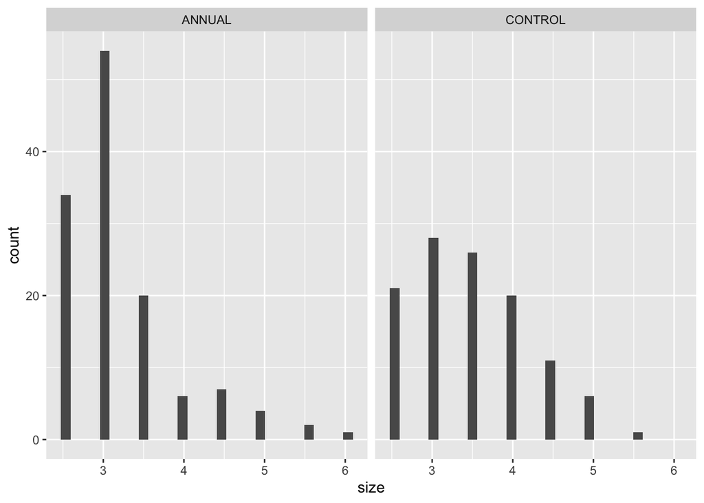

```r
# Exploratory Histograms for the purple urchin size distribution separated by treatment in Naples Reef 2010.

ggplot(data= purple_naples_2010, aes(x = size)) +
  geom_histogram() +
  facet_wrap(~ treatment)
```

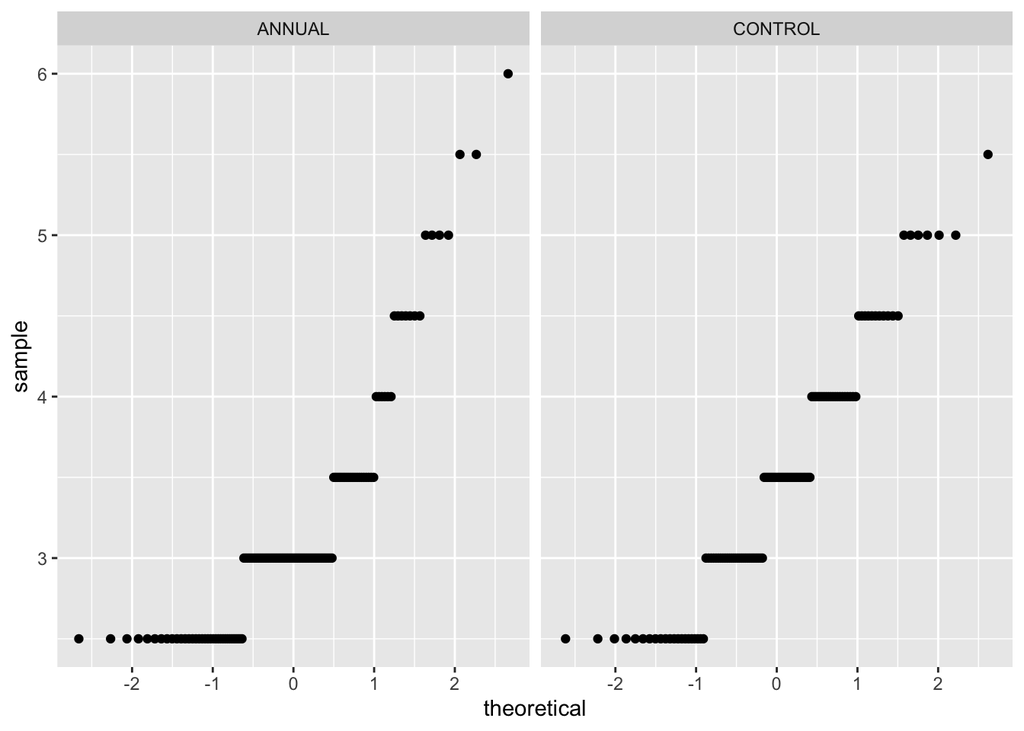

```r
# Exploratory QQ-plots for the purple urchin size distribution separated by treatment in Naples Reef 2010.

ggplot(data = purple_naples_2010, aes(sample = size)) +
  geom_qq() +
  facet_wrap(~ treatment)
```

In the histograms, the pattern in purple sea urchin distribution shows that with the annual treatment of giant kelp being removed, there are more small purple sea urchins with a big peak at 3 cm while in the control where the giant kelp is left intact the sizes vary less dramatically so the sizes are more evenly distributed among the population. In the qq-plots this pattern is harder to see and but we do see that the pattern overall is “shorter” in the control group.

## Data Wrangling

Here I created a subset for the purple_naples_2010 data and called it purple_naples10_summary. I found the mean, median, standard deviation and sample size for the purple urchins in the Naples Reef for 2010.

```r
purple_naples10_summary <- purple_naples_2010 %>%
  group_by(common_name, treatment) %>%
  summarize(mean_size = round(mean(size), 2),
            median_size = round(median(size), 2),
            sd_size = round(sd(size), 2),
            sample_size = n()
            )
```

## Data Visualization- Summary table

Here I created the summary table based from the purple_naples10_summary subset for purple sea urchins from the Naples Reef in 2010.

```r
purple_naples10_summary %>%
  kbl(caption = "Table 1- Summary table for Purple Sea Urchins from Naples Reef in 2010",
      col.names= c("Common Name",
                   "Treatment",
                   "Mean Size (cm)",
                   "Median Size (cm)",
                   "Standard Deviation",
                   "Sample Size")) %>%
  kable_classic_2(full_width = F)
```

Table 1- Summary table for Purple Sea Urchins from Naples Reef in 2010

| Common Name | Treatment | Mean Size (cm) | Median Size (cm) | Standard Deviation | Sample Size |
| --- | --- | --- | --- | --- | --- |
| Purple Urchin | ANNUAL | 3.20 | 3.0 | 0.73 | 128 |
| Purple Urchin | CONTROL | 3.47 | 3.5 | 0.74 | 113 |